# Bio244 - LAB 7 - Regression

Gabriel Perron

2019/02/20

# Question 1

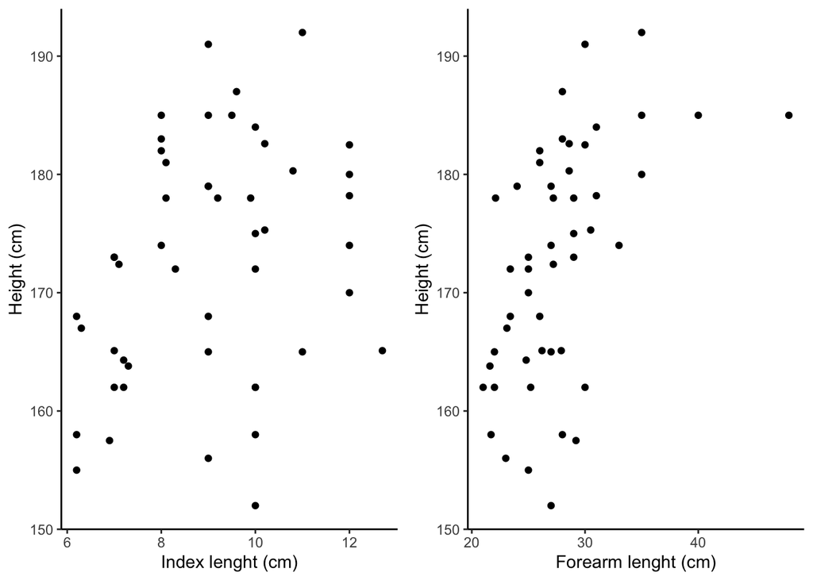

```r
Figure1A <- ggplot(HUMAN, aes(x=HUMAN$INDEX, y=HUMAN$HEIGHT),title="(A)") +
            geom_point() +
            xlab("Index lenght (cm)") +
            ylab("Height (cm)") +
            theme_classic()
Figure1B <- ggplot(HUMAN, aes(x=HUMAN$FORE, y=HUMAN$HEIGHT),title="(B)") +
            geom_point() +
            xlab("Forearm lenght (cm)") +
            ylab("Height (cm)") +
            theme_classic()

grid.arrange(Figure1A, Figure1B, ncol=2)
```

**Figure 1.** The relationship between human heigth (cm) and **A)** index length (com); and **B)** forearm length (cm).

# Question 2

## Does index predict height

H<sub>0</sub>: Height is not explained/predicted by index length;  
H<sub>A</sub>: Height is explained/predicted by index length;

```r
model.index <- lm(HUMAN$HEIGHT~HUMAN$INDEX)
anova(model.index)
```

```
## Analysis of Variance Table
##
## Response: HUMAN$HEIGHT
##             Df Sum Sq Mean Sq F value  Pr(>F)
## HUMAN$INDEX  1  432.0  431.99  4.5649 0.03787 *
## Residuals   47 4447.7   94.63
## ---
## Signif. codes:  0 '***' 0.001 '**' 0.01 '*' 0.05 '.' 0.1 ' ' 1
```

**Conclusion**: We reject H<sub>0</sub>. Therefore, Height is predicted by index length; (*F*<sub>(1,47)</sub> = 4.57; *P* = 0.038).

**Estimating regression parameters**

```r
summary(model.index)
```

```
##
## Call:
## lm(formula = HUMAN$HEIGHT ~ HUMAN$INDEX)
##
## Residuals:
##      Min       1Q   Median       3Q      Max
## -22.2409  -7.5135   0.7215   6.4475  18.4475
##
## Coefficients:
##             Estimate Std. Error t value Pr(>|t|)
## (Intercept) 157.3576     7.2654  21.659   <2e-16 ***
## HUMAN$INDEX   1.6883     0.7902   2.137   0.0379 *
## ---
## Signif. codes:  0 '***' 0.001 '**' 0.01 '*' 0.05 '.' 0.1 ' ' 1
##
## Residual standard error: 9.728 on 47 degrees of freedom
## Multiple R-squared:  0.08853,    Adjusted R-squared:  0.06913
## F-statistic: 4.565 on 1 and 47 DF,  p-value: 0.03787
```

**Equation:** y = 157.36 + 1.69x; *R*<sup>2</sup> = 0.069

## Does forearm predict height

H<sub>0</sub>: Height is not explained/predicted by forearm length;  
H<sub>A</sub>: Height is explained/predicted by forearm length;

```r
model.fore <- lm(HUMAN$HEIGHT~HUMAN$FORE)
anova(model.fore)
```

```
## Analysis of Variance Table
##
## Response: HUMAN$HEIGHT
##            Df Sum Sq Mean Sq F value   Pr(>F)
## HUMAN$FORE  1 1447.1 1447.07  19.814 5.23e-05 ***
## Residuals  47 3432.6   73.03
## ---
## Signif. codes:  0 '***' 0.001 '**' 0.01 '*' 0.05 '.' 0.1 ' ' 1
```

**Conclusion**: We reject H<sub>0</sub>. Therefore, Height is predicted by forearm length; (*F*<sub>(1,47)</sub> = 19.81; *P* < 0.0001).

**Estimating regression parameters**

```r
summary(model.fore)
```

```
##
## Call:
## lm(formula = HUMAN$HEIGHT ~ HUMAN$FORE)
##
## Residuals:
##     Min      1Q  Median      3Q     Max
## -19.807  -5.062   0.194   6.715  15.859
##
## Coefficients:
##             Estimate Std. Error t value Pr(>|t|)
## (Intercept) 141.8006     7.0248  20.186  < 2e-16 ***
## HUMAN$FORE    1.1113     0.2497   4.451 5.23e-05 ***
## ---
## Signif. codes:  0 '***' 0.001 '**' 0.01 '*' 0.05 '.' 0.1 ' ' 1
##
## Residual standard error: 8.546 on 47 degrees of freedom
## Multiple R-squared:  0.2965, Adjusted R-squared:  0.2816
## F-statistic: 19.81 on 1 and 47 DF,  p-value: 5.23e-05
```

**Equation:** y = 141.8 + 1.11x; *R*<sup>2</sup> = 0.28

## Correting for multiplicity of p-value

Here is a good example of a situation where one should apply a Bonferonni correction. If you think about it, it would be possible to try to predict human heigth from hundred of different bones, thus running the chance to find one that is significant by chance along. For this reason, we will apply the following correction:

**Adjusted P-value for index**

```r
p.adjust(0.038, method = "bonferroni", n= 2)
```

```
## [1] 0.076
```

**New Conclusion**: We fail to reject H<sub>0</sub>. Therefore, Height is not predicted by index length; (*F*<sub>(1,47)</sub> = 4.57; adj-*P* = 0.08).

**Adjusted P-value for forearm**

```r
p.adjust(5.23e-05, method = "bonferroni", n= 2)
```

```
## [1] 0.0001046
```

# Question 3

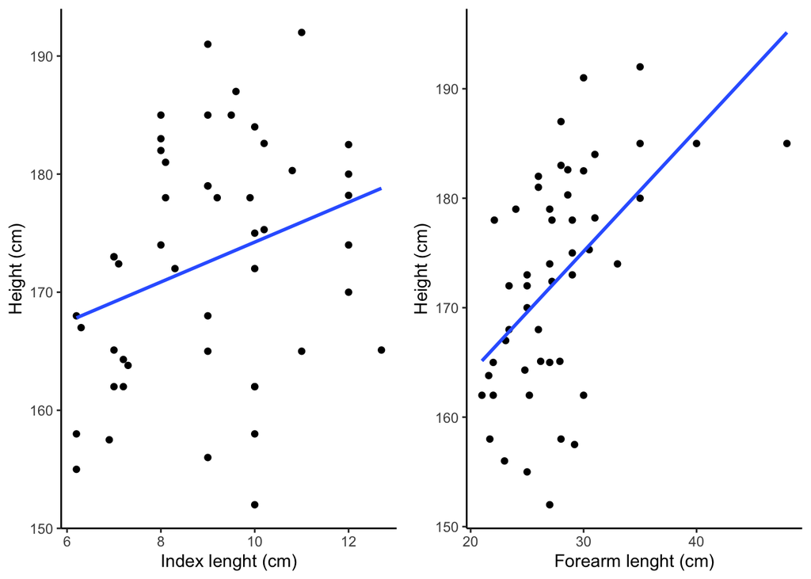

```r
Figure2A <- ggplot(HUMAN, aes(x=HUMAN$INDEX, y=HUMAN$HEIGHT),title="(A)") +
            geom_point() +
            geom_smooth(method='lm', se = FALSE) +
            xlab("Index lenght (cm)") +
            ylab("Height (cm)") +
            theme_classic()
  Figure2B <- ggplot(HUMAN, aes(x=HUMAN$FORE, y=HUMAN$HEIGHT),title="(B)") +
            geom_point() +
            geom_smooth(method='lm', se = FALSE) +
            xlab("Forearm lenght (cm)") +
            ylab("Height (cm)") +
            theme_classic()

grid.arrange(Figure2A, Figure2B, ncol=2)
```

**Figure 2.** Human height **A)** cannot be predicted by index lenght (*F*<sub>(1,47)</sub> = 4.57; adj-*P* = 0.08; y = 157.36 + 1.69x; *R*<sup>2</sup> = 0.069); and **B)** can be predicted by forearm (*F*<sub>(1,47)</sub> = 19.81; adj-*P* = 0.0001;y = 141.8 + 1.11x; *R*<sup>2</sup> = 0.28).

## Question 4

Based on the fact that only forearm was significant after correcting for multiple comparisons, I conclude that forearm is the best predictor. In addition, the *R*<sup>2</sup> value is larger.